# Reproducible Research: Peer Assessment 1

Branislav Adamovic

July 20, 2017

# Activity Data Analysis

This assignment makes use of data from a personal activity monitoring device.he data consists of two months of data from an anonymous individual collected during the months of October and November, 2012 and include the number of steps taken in 5 minute intervals each day.

As a first step we will load the data and store it to a variable:

```r
activity<-read.csv("activity.csv")
```

then change column date from factor to date format:

```r
activity$date<-as.Date(as.character(activity$date))
```

and finally load necessary package:

```r
library(dplyr)
library(lattice)
```

### Now, we will go through given tasks:

**1. Plot histogram of the total number of steps taken each day.**

Firstly we have to create sum of steps for each day and store it to variable called “perDay”.

```r
perDay<- activity %>%
        group_by(date) %>%
        summarise(daySteps=sum(steps, na.rm=TRUE))
```

Secondly we draw the histogram.

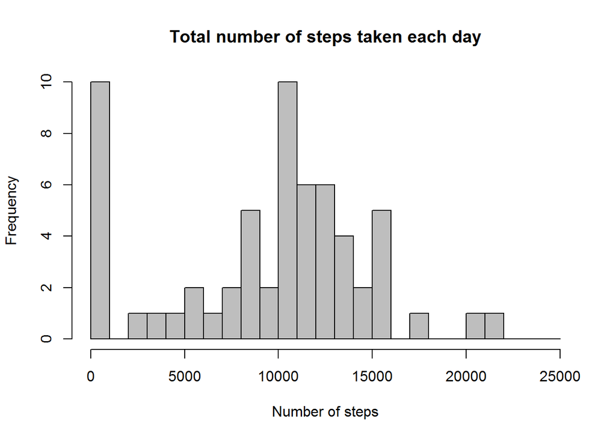

```r
with(perDay, {
        hist(daySteps, breaks = seq(0,25000, by=1000), col = "grey", main = "Total number of steps taken each day", xlab = "Number of steps")
})
```

**2. Calculate mean and median number of steps taken each day**

Mean

```r
mean(perDay$daySteps)
```

```
## [1] 9354.23
```

Median

```r
median(perDay$daySteps)
```

```
## [1] 10395
```

**3. Time series plot of the average number of steps taken**

Calculation of average steps taken accross all days.

```r
averageSteps <-activity %>%
        group_by(interval) %>%
        summarise(intervalMean=mean(steps, na.rm=TRUE))
```

And, plotting time series.

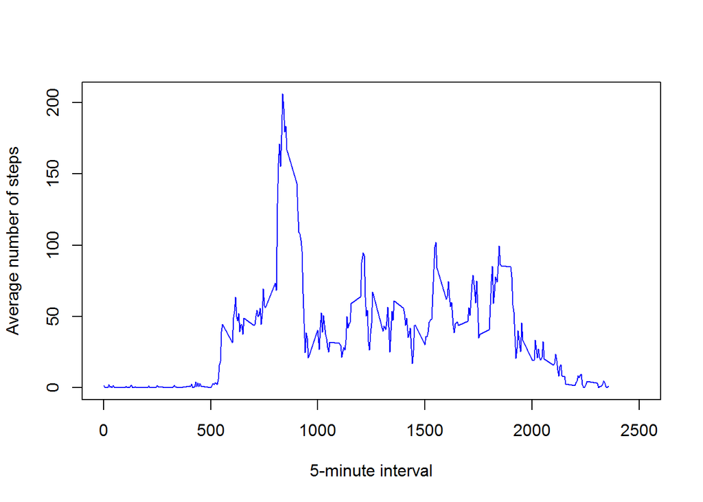

```r
with(averageSteps, {
        plot(interval, intervalMean, type="l", xlab="5-minute interval", ylab = "Average number of steps", col="blue", xlim = c(0, 2500))
})
```

**4. The 5-minute interval that, on average, contains the maximum number of steps**

```r
 averageSteps[which.max(averageSteps$intervalMean),]$interval
```

```
## [1] 835
```

**5. Code to describe and show a strategy for imputing missing data**

Note that there are a number of days/intervals where there are missing values (coded as NA). The presence of missing days may introduce bias into some calculations or summaries of the data.